# Heart AI Comparison

## Random Forest

We will use a random forest AI method to model the hypothesis. It uses a random selection of 500 repetitions of many decision trees to create the best predictions. It might not do as well next time, but might also do better. How do you explain that to the client? We perform the random forest model on all variables, making them numeric.Run the model.

```r
library(randomForest)
fit.rf.all = randomForest(RestBP~.-Obs, data=Heartoh, type="regression")
fit.rf.all %>% print
```

```
Call:
 randomForest(formula = RestBP ~ . - Obs, data = Heartoh, type = "regression")
               Type of random forest: regression
                     Number of trees: 500
No. of variables tried at each split: 9

          Mean of squared residuals: 306.0666
                    % Var explained: 2.67
```

```r
pred.rf.all = predict(fit.rf.all, newdata=Heartoh)
pred.rf.all %>% summary
```

```
   Min. 1st Qu.  Median    Mean 3rd Qu.    Max.
  108.2   124.3   130.4   131.7   138.0   172.7
```

Compute accuracy.

```r
accuracy.rmse.rf.all = mltools::rmse(pred.rf.all, Heartoh$RestBP)
accuracy.rmse.rf.all
```

```
[1] 8.140676
```

The accuracy is 8.1406757.

### Visualization

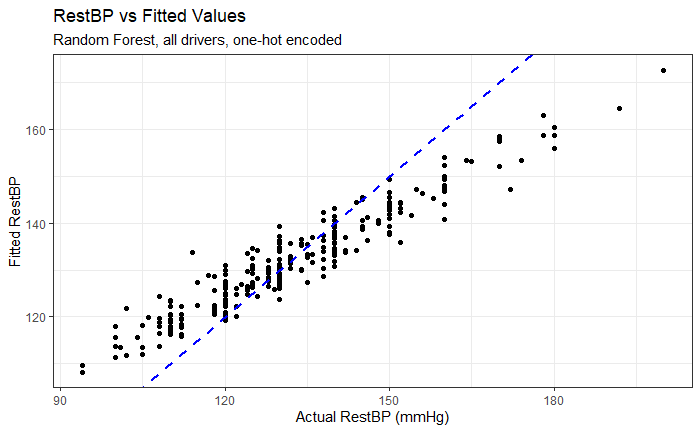

```r
plot.rf.all = ggplot(Heartoh) +
  geom_point(aes(RestBP, pred.rf.all))+
  geom_abline(aes(slope=1, intercept=0), color="blue", linetype="dashed", linewidth=1) +
  theme_bw() +
  labs(title="RestBP vs Fitted Values",
       subtitle="Random Forest, all drivers, one-hot encoded",
       x="Actual RestBP (mmHg)", y="Fitted RestBP")
plot.rf.all
```

The random forest seems biased to forecast low values too high and high values too low. A good fit should be right on the dotted line. It’s a much more focused than the neural network.

## K-nearest neighbors

This model can also be used; the best version comes from package `FNN`. We try it using 3 nearest neighbors, the value of parameter ‘k’. We scale the data, though that should not be necessary. Now we try all variables.

```r
library(FNN)
fit.knn.all<- knn.reg(Heartoh.scaled %>% select(-RestBP, -Obs), y=Heartoh.scaled$RestBP, k=3)
pred.kk.all.unscaled = mean(Heartoh$RestBP) + fit.knn.all$pred*sd(Heartoh$RestBP)
```

Now compute the RMSE accuracy measure.

```r
accuracy.rmse.kk.all = mltools::rmse(pred.kk.all.unscaled, Heartall$RestBP)
accuracy.rmse.kk.all
```

```
[1] 18.5507
```

Not good.

### Visualization

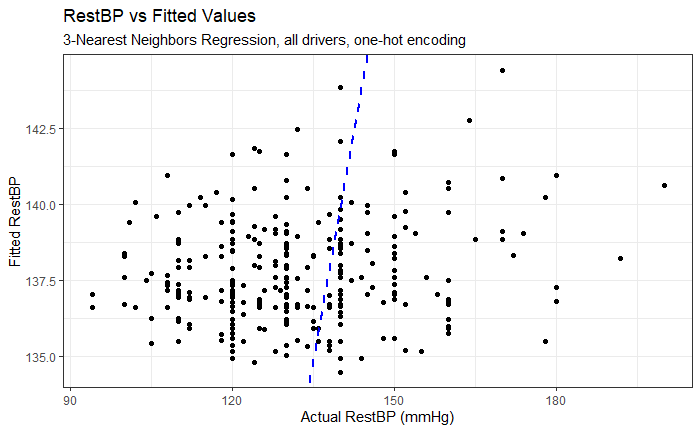

```r
plot.kk.all = ggplot(Heartoh) +
  geom_point(aes(RestBP, pred.kk.all.unscaled))+
  geom_abline(aes(slope=1, intercept=0), color="blue", linetype="dashed", linewidth=1) +
  theme_bw() +
  labs(title="RestBP vs Fitted Values",
       subtitle="3-Nearest Neighbors Regression, all drivers, one-hot encoding",
       x="Actual RestBP (mmHg)", y="Fitted RestBP")
plot.kk.all
```

Not so good either.

# Comparing the Models

## Accuracy

First compare accuracies.

```r
library(DT)
AccuracyComparisonAllOH = data.frame(OLS = accuracy.rmse.lm.all,
                                NNET = accuracy.rmse.nn.all,
                                RF = accuracy.rmse.rf.all,
                                KNN = accuracy.rmse.kk.all) %>%
  round(digits=4)
AccuracyComparisonAllOH %>% mutate(Measure = "RMSE", .before=1) %>%
  DT::datatable(caption="Accuracy Comparison, all drivers, one-hot encoding")
```

|  | Measure | OLS | NNET | RF | KNN |
| --- | --- | --- | --- | --- | --- |
| 1 | RMSE | 15.8178 | 10.5335 | 8.1407 | 18.5507 |

The neural net does well, but the random forest is better.

We save this comparison table for use with other AI routines.

```r
saveRDS(AccuracyComparisonAllOH, file = "AccuracyComparisonAllOH.rds")
```

## Visualizations

Now for all variables.

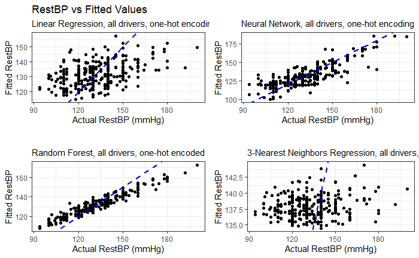

```r
new('ggmultiplot', ncol=2, plots = list(plot.lm.all,
                                        plot.nn.all + ggtitle(""),
                                        plot.rf.all + ggtitle(""),
                                        plot.kk.all + ggtitle(""))
)
```

# Conclusion

We used the Heart data to fit models using linear regression and some AI methods, a neural network and a random forest, and k-nearest neighbors regression.

With this data, the random forest gave the best fit, using RMSE as an accuracy measure. However we can see the bias in the results, predicting too high for low actual RestBP and too low for high RestBP. So the random forest might not be so useful.

The neural network had a lot of errors when it predicted around 130, though it was better above and below. We might want to explore a different hidden layer structure.

We also saw that the random forest method seemed to have a bias. The linear model, by design, did not; the mistakes it made were equally on each side, above or below. Neither did the neural network. Can we find a way to take the bias out of the random forest, to take advantage of its closer predictions?

Ideally we should do this experiment using crossvalidation, by dividing the dataset into two parts, training on the first part, and testing (predicting) on the second part. More about that later in the class. We need to do that because the AI methods use randomness in their processes, and you don’t get the same result each time. Also we want the model to be *robust*, be able to make predictions on data it has not been trained on. Crossvalidation is perfect for that.

# References

1. [Create a Q-Q Plot](https://www.statology.org/ggplot-q-q-plot/)
2. [xgboost for Regression](https://www.projectpro.io/recipes/apply-xgboost-r-for-regression)